```python
import numpy as np
import pandas as pd
import matplotlib.pyplot as plt
import seaborn as sns
%matplotlib inline
```

# #Reading the data set

```python
Hotel_Bookings = pd.read_excel("C:/Users/Vidhut Sharma/Desktop/hotel_bookings_Capstone1.xlsx")
Hotel_Bookings.head(10)
```

|  | hotel | is_canceled | booking_date | arrival_date | stays_in_weekend_nights | stays_in_week_nights | adults | children | meal | country | ... | reserved_room_type | assigned_room_type | booking_changes | deposit_type | agent | company | days_in_waiting_list | customer_type | required_car_parking_spaces | totalno_of_special_requests |
| --- | --- | --- | --- | --- | --- | --- | --- | --- | --- | --- | --- | --- | --- | --- | --- | --- | --- | --- | --- | --- | --- |
| 0 | type_2 | 0 | 2017-07-24 | 2018-07-01 | 0 | 0 | 2 | 0 | Only Breakfast | PRT | ... | C | C | 3 | No Deposit | NaN | NaN | 0 | Transient | 0 | 0 |
| 1 | type_2 | 0 | 2016-06-24 | 2018-07-01 | 0 | 0 | 2 | 0 | Only Breakfast | PRT | ... | C | C | 4 | No Deposit | NaN | NaN | 0 | Transient | 0 | 0 |
| 2 | type_2 | 0 | 2018-06-24 | 2018-07-01 | 0 | 1 | 1 | 0 | Only Breakfast | GBR | ... | A | C | 0 | No Deposit | NaN | NaN | 0 | Transient | 0 | 0 |
| 3 | type_2 | 0 | 2018-06-18 | 2018-07-01 | 0 | 1 | 1 | 0 | Only Breakfast | GBR | ... | A | A | 0 | No Deposit | 304.0 | NaN | 0 | Transient | 0 | 0 |
| 4 | type_2 | 0 | 2018-06-17 | 2018-07-01 | 0 | 2 | 2 | 0 | Only Breakfast | GBR | ... | A | A | 0 | No Deposit | 240.0 | NaN | 0 | Transient | 0 | 1 |
| 5 | type_2 | 0 | 2018-06-17 | 2018-07-01 | 0 | 2 | 2 | 0 | Only Breakfast | GBR | ... | A | A | 0 | No Deposit | 240.0 | NaN | 0 | Transient | 0 | 1 |
| 6 | type_2 | 0 | 2018-07-01 | 2018-07-01 | 0 | 2 | 2 | 0 | Only Breakfast | PRT | ... | C | C | 0 | No Deposit | NaN | NaN | 0 | Transient | 0 | 0 |
| 7 | type_2 | 0 | 2018-06-22 | 2018-07-01 | 0 | 2 | 2 | 0 | Breakfast, lunch & dinner | PRT | ... | C | C | 0 | No Deposit | 303.0 | NaN | 0 | Transient | 0 | 1 |
| 8 | type_2 | 1 | 2018-04-07 | 2018-07-01 | 0 | 3 | 2 | 0 | Only Breakfast | PRT | ... | A | A | 0 | No Deposit | 240.0 | NaN | 0 | Transient | 0 | 1 |
| 9 | type_2 | 1 | 2018-04-17 | 2018-07-01 | 0 | 3 | 2 | 0 | Breakfast & dinner | PRT | ... | D | D | 0 | No Deposit | 15.0 | NaN | 0 | Transient | 0 | 0 |

10 rows × 25 columns

```python
Hotel_Bookings[Hotel_Bookings["deposit_type"] == "Non Refund"]["is_canceled"].value_counts()
```

```
1    14494
0       93
Name: is_canceled, dtype: int64
```

# Checking the number of rows and column for the data

```python
Hotel_Bookings.shape
```

```
(119390, 25)
```

# Checking the data types of the data and for the missing values and NA values

```python
Hotel_Bookings.info()
```

```
<class 'pandas.core.frame.DataFrame'>
RangeIndex: 119390 entries, 0 to 119389
Data columns (total 25 columns):
 #   Column                          Non-Null Count   Dtype
---  ------                          --------------   -----
 0   hotel                           119390 non-null  object
 1   is_canceled                     119390 non-null  int64
 2   booking_date                    119390 non-null  datetime64[ns]
 3   arrival_date                    119390 non-null  datetime64[ns]
 4   stays_in_weekend_nights         119390 non-null  int64
 5   stays_in_week_nights            119390 non-null  int64
 6   adults                          119390 non-null  int64
 7   children                        119390 non-null  int64
 8   meal                            119390 non-null  object
 9   country                         118902 non-null  object
```

[output cut: 17 more lines]

```python
#Na Values check
Hotel_Bookings.isnull().sum()
```

```
hotel                                  0
is_canceled                            0
booking_date                           0
arrival_date                           0
stays_in_weekend_nights                0
stays_in_week_nights                   0
adults                                 0
children                               0
meal                                   0
country                              488
market_segment                         0
distribution_channel                   0
is_repeated_customer                   0
previous_cancellations                 0
previous_bookings_not_canceled         0
reserved_room_type                     0
assigned_room_type                     0
booking_changes                        0
deposit_type                           0
agent                              16340
company                           112593
days_in_waiting_list                   0
customer_type                          0
required_car_parking_spaces            0
totalno_of_special_requests            0
dtype: int64
```

Dropping the Features which are Country , Agent and Company as these are not the parameters which we can say will impactthe hotel cancellation and if we observe there are around 1 lakh + rows empty in the company column .If we remove that many NA values we may loose lot of our useful insights.

```python
Hotel_Bookings.drop(["country","agent","company"],axis=1,inplace = True)
```

```python
#Na Values check after removal of variables
Hotel_Bookings.isnull().sum()
```

```
hotel                             0
is_canceled                       0
booking_date                      0
arrival_date                      0
stays_in_weekend_nights           0
stays_in_week_nights              0
adults                            0
children                          0
meal                              0
market_segment                    0
distribution_channel              0
is_repeated_customer              0
previous_cancellations            0
previous_bookings_not_canceled    0
reserved_room_type                0
assigned_room_type                0
booking_changes                   0
deposit_type                      0
days_in_waiting_list              0
customer_type                     0
required_car_parking_spaces       0
totalno_of_special_requests       0
dtype: int64
```

```python
Hotel_Bookings
```

|  | hotel | is_canceled | booking_date | arrival_date | stays_in_weekend_nights | stays_in_week_nights | adults | children | meal | market_segment | ... | previous_cancellations | previous_bookings_not_canceled | reserved_room_type | assigned_room_type | booking_changes | deposit_type | days_in_waiting_list | customer_type | required_car_parking_spaces | totalno_of_special_requests |
| --- | --- | --- | --- | --- | --- | --- | --- | --- | --- | --- | --- | --- | --- | --- | --- | --- | --- | --- | --- | --- | --- |
| 0 | type_2 | 0 | 2017-07-24 | 2018-07-01 | 0 | 0 | 2 | 0 | Only Breakfast | Direct | ... | 0 | 0 | C | C | 3 | No Deposit | 0 | Transient | 0 | 0 |
| 1 | type_2 | 0 | 2016-06-24 | 2018-07-01 | 0 | 0 | 2 | 0 | Only Breakfast | Direct | ... | 0 | 0 | C | C | 4 | No Deposit | 0 | Transient | 0 | 0 |
| 2 | type_2 | 0 | 2018-06-24 | 2018-07-01 | 0 | 1 | 1 | 0 | Only Breakfast | Direct | ... | 0 | 0 | A | C | 0 | No Deposit | 0 | Transient | 0 | 0 |
| 3 | type_2 | 0 | 2018-06-18 | 2018-07-01 | 0 | 1 | 1 | 0 | Only Breakfast | Corporate | ... | 0 | 0 | A | A | 0 | No Deposit | 0 | Transient | 0 | 0 |
| 4 | type_2 | 0 | 2018-06-17 | 2018-07-01 | 0 | 2 | 2 | 0 | Only Breakfast | Online Travel Agents | ... | 0 | 0 | A | A | 0 | No Deposit | 0 | Transient | 0 | 1 |
| ... | ... | ... | ... | ... | ... | ... | ... | ... | ... | ... | ... | ... | ... | ... | ... | ... | ... | ... | ... | ... | ... |
| 119385 | type_1 | 0 | 2020-08-07 | 2020-08-30 | 2 | 5 | 2 | 0 | Only Breakfast | Offline Travel Agents/Operators | ... | 0 | 0 | A | A | 0 | No Deposit | 0 | Transient | 0 | 0 |
| 119386 | type_1 | 0 | 2020-05-21 | 2020-08-31 | 2 | 5 | 3 | 0 | Only Breakfast | Online Travel Agents | ... | 0 | 0 | E | E | 0 | No Deposit | 0 | Transient | 0 | 2 |
| 119387 | type_1 | 0 | 2020-07-28 | 2020-08-31 | 2 | 5 | 2 | 0 | Only Breakfast | Online Travel Agents | ... | 0 | 0 | D | D | 0 | No Deposit | 0 | Transient | 0 | 4 |
| 119388 | type_1 | 0 | 2020-05-14 | 2020-08-31 | 2 | 5 | 2 | 0 | Only Breakfast | Online Travel Agents | ... | 0 | 0 | A | A | 0 | No Deposit | 0 | Transient | 0 | 0 |
| 119389 | type_1 | 0 | 2020-02-06 | 2020-08-29 | 2 | 7 | 2 | 0 | Breakfast & dinner | Online Travel Agents | ... | 0 | 0 | A | A | 0 | No Deposit | 0 | Transient | 0 | 2 |

119390 rows × 22 columns

Now checking the difference between the booking date and arrival date. The difference will suggest us on how many days prior the arrival the customer books the hotel.

```python
Df_Of_Dates_Diff = pd.DataFrame({"booking_date": Hotel_Bookings["booking_date"],"arrival_date" : Hotel_Bookings['arrival_date'],"Difference":Hotel_Bookings['arrival_date'] - Hotel_Bookings["booking_date"]})
G = str(Df_Of_Dates_Diff["Difference"][0])
int(G.split()[0])
Dates_DiffList = []
for i in range(0,len(Df_Of_Dates_Diff["Difference"])):
    G = str(Df_Of_Dates_Diff["Difference"][i])
    Dates_DiffList.append(int(G.split()[0]))
Df_Of_Dates_Diff["Difference"] = Dates_DiffList
```

Adding the Difference of dates in the Main Data of Hotel Cancellation

```python
Hotel_Bookings["Difference_Between_Booking_Arrival_Dates"] = Df_Of_Dates_Diff["Difference"]
```

```python
Hotel_Bookings["meal"].value_counts()
```

```
Only Breakfast               92310
Breakfast & dinner           14463
No meal                      11819
Breakfast, lunch & dinner      798
Name: meal, dtype: int64
```

# Starting the Univariate and Bivariate Analysis

```python
Hotel_Bookings["meal"].dtypes =="object"
```

```
True
```

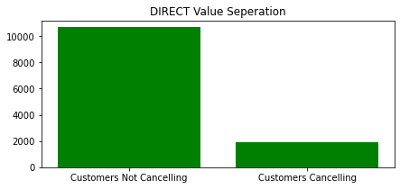

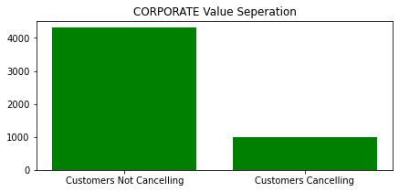

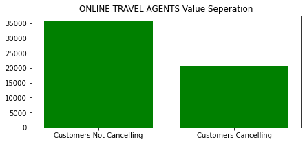

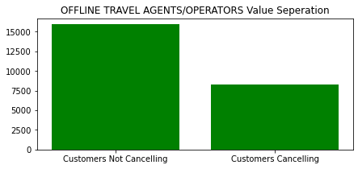

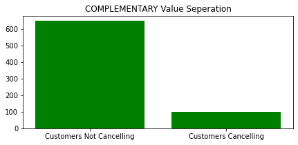

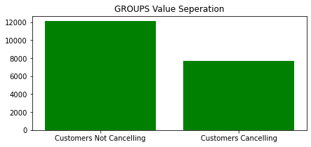

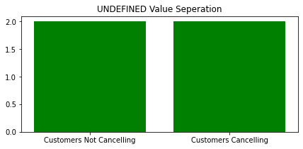

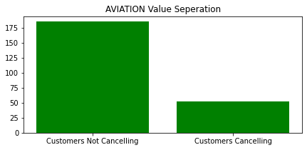

```python
Hotel_Bookings["is_canceled"].unique()

for name in Hotel_Bookings["market_segment"].unique():
    fig = plt.figure(figsize = (7, 3))
    plt.bar(("Customers Not Cancelling","Customers Cancelling"),Hotel_Bookings[Hotel_Bookings["market_segment"]==name]["is_canceled"].value_counts(),color = "green")
    plt.title(name.upper() + " Value Seperation")
    plt.show()
#sns.barplot(x = Hotel_Bookings["is_canceled"].unique(),y = Hotel_Bookings[Hotel_Bookings["market_segment"]=="Online Travel Agents"]["is_canceled"].value_counts())
```

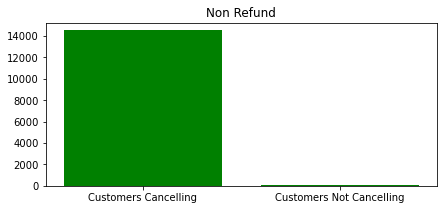

```python
Hotel_Bookings["is_canceled"].unique()

#for name in Hotel_Bookings["deposit_type"].unique():
fig = plt.figure(figsize = (7, 3))
plt.bar(("Customers Cancelling","Customers Not Cancelling"),Hotel_Bookings[Hotel_Bookings["deposit_type"]=="Non Refund"]["is_canceled"].value_counts(),color = "green")
plt.title("Non Refund")
plt.show()
```

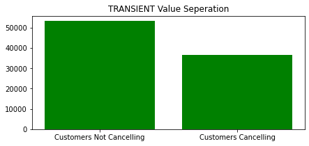

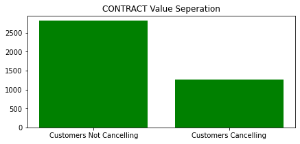

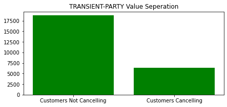

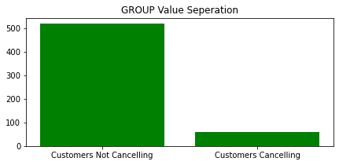

```python
for name in Hotel_Bookings["customer_type"].unique():
    fig = plt.figure(figsize = (7, 3))
    plt.bar(("Customers Not Cancelling","Customers Cancelling"),Hotel_Bookings[Hotel_Bookings["customer_type"]==name]["is_canceled"].value_counts(),color = "green")
    plt.title(name.upper() + " Value Seperation")
    plt.show()
```

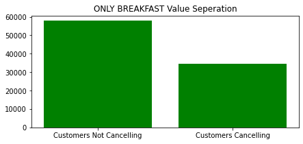

```
0    57800
1    34510
Name: is_canceled, dtype: int64 92310
```

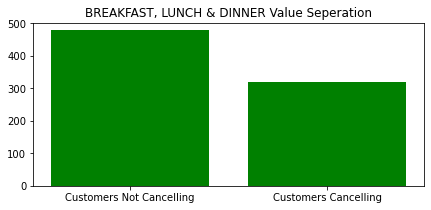

```
1    478
0    320
Name: is_canceled, dtype: int64 798
```

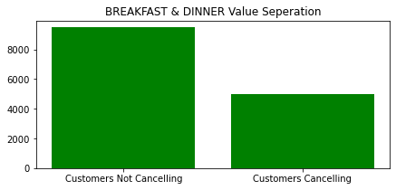

```
0    9479
1    4984
Name: is_canceled, dtype: int64 14463
```

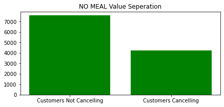

```
0    7567
1    4252
Name: is_canceled, dtype: int64 11819
```

```python
for name in Hotel_Bookings["meal"].unique():
    fig = plt.figure(figsize = (7, 3))
    plt.bar(("Customers Not Cancelling","Customers Cancelling"),Hotel_Bookings[Hotel_Bookings["meal"]==name]["is_canceled"].value_counts(),color = "green")
    plt.title(name.upper() + " Value Seperation")
    plt.show()
    print(Hotel_Bookings[Hotel_Bookings["meal"]==name]["is_canceled"].value_counts(),sum(Hotel_Bookings[Hotel_Bookings["meal"]==name]["is_canceled"].value_counts()))
```

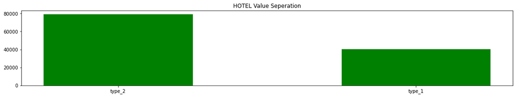

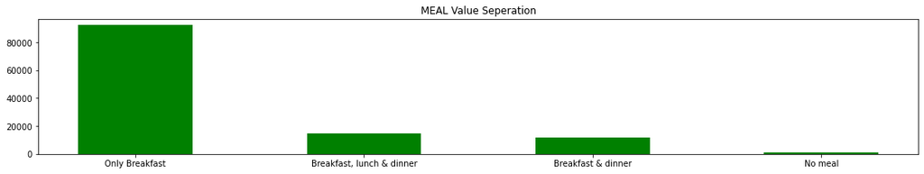

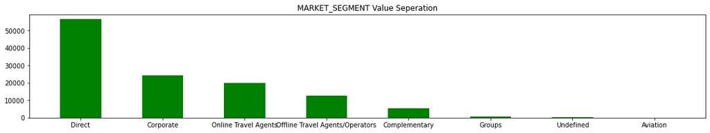

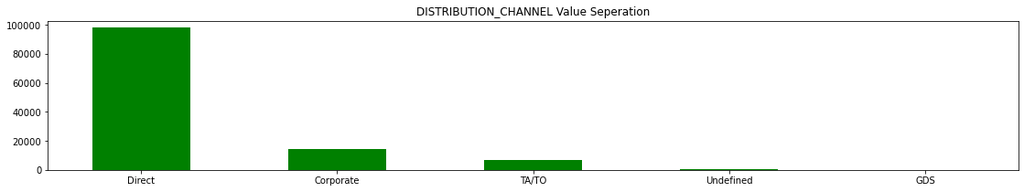

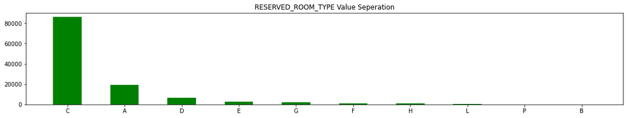

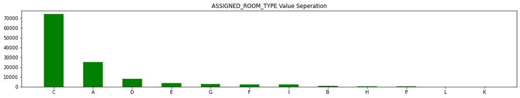

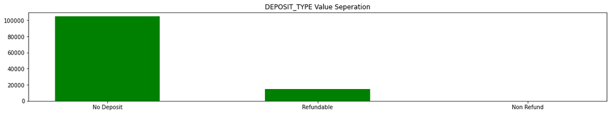

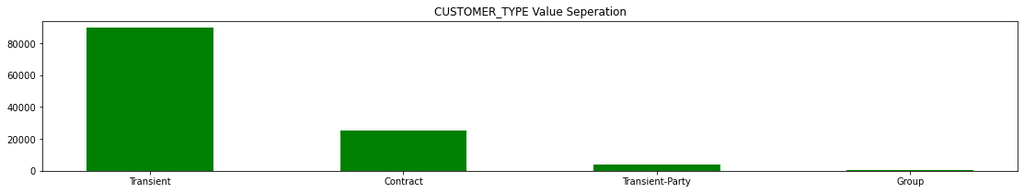

```python
for name in Hotel_Bookings.columns:
    if Hotel_Bookings[name].dtypes == "object":
        fig = plt.figure(figsize = (19, 3))
        plt.bar(Hotel_Bookings[name].unique(),Hotel_Bookings[name].value_counts(),color = "green",width =0.5)
        plt.title(name.upper() + " Value Seperation")
        plt.show()
```

For the Bivariate Analysis we will be using the pairplot as it gives relationship with the dependent variable and independent variables and between independent and indepedent variable as well

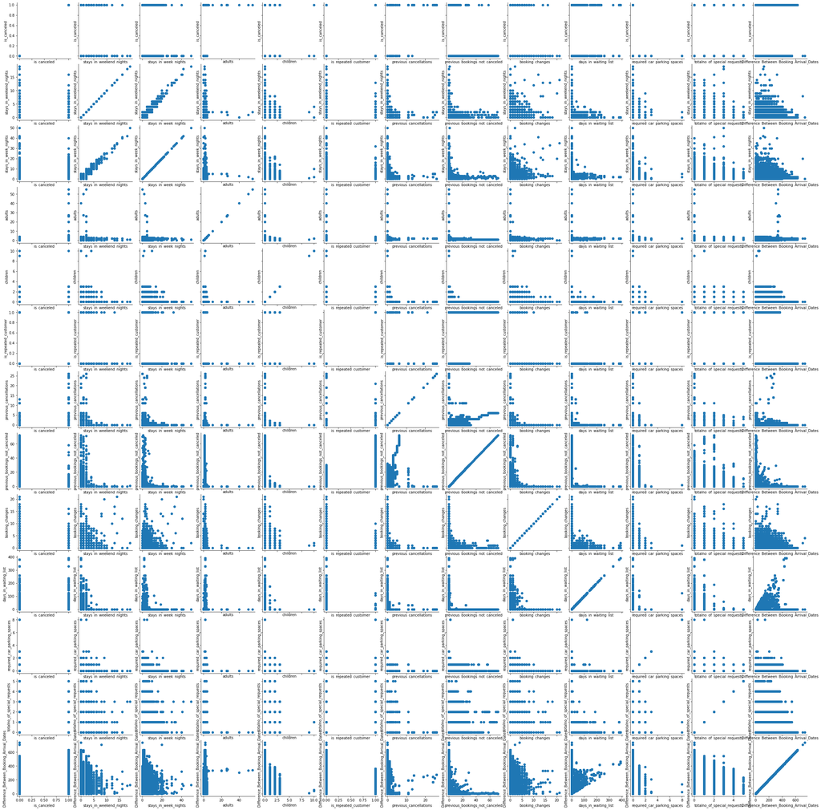

```python
#sns.pairplot(Hotel_Bookings,aspect = 0.5);
#sns.PairGrid(Hotel_Bookings,aspect = 0.5)
Hotel_Data = sns.PairGrid(Hotel_Bookings,)
Hotel_Data = Hotel_Data.map(plt.scatter)

x_label,y_label = [],[]

for ax in Hotel_Data.axes[-1,:]:
    x_lab = ax.xaxis.get_label_text()
    x_label.append(x_lab)
for ax in Hotel_Data.axes[:,0]:
    y_lab = ax.yaxis.get_label_text()
    y_label.append(y_lab)

for i in range(len(x_label)):
    for j in range(len(y_label)):
        Hotel_Data.axes[j,i].xaxis.set_label_text(x_label[i])
        Hotel_Data.axes[j,i].yaxis.set_label_text(y_label[j])

plt.show()
```